# Midterm Assignemnt, ME314 2019

Zhixiang Lin

[figure not shown]

#### Summer School 2019 midsession examination

# ME314 Introduction to Data Science and Machine Learning

## Suitable for all candidates

### Instructions to candidates

- Complete the assignment by adding your answers directly to the RMarkdown document, knitting the document, and submitting the HTML file to Moodle.
- Time allowed: due 19:00 on Wednesday, 7th August 2019.
- Submit the assignment via [Moodle](https://shortcourses.lse.ac.uk/course/view.php?id=158).

## Question 1:

This question should be answered using the `Carseats` data set, which is part of the **ISLR** package. This data contains simulated data set containing sales of child car seats at 400 different stores.

```r
data("Carseats", package = "ISLR")
```

1. Fit a regression model predicting Sales using Advertising and Price as predictors. Interpret the coefficients, the $R^2$, and the Residual standard error from the regression (by explaining each in a few statements).

##answer:

```r
lm.fit <- lm(Sales ~ Advertising + Price, data = Carseats)
summary(lm.fit)
```

```
##
## Call:
## lm(formula = Sales ~ Advertising + Price, data = Carseats)
##
## Residuals:
##     Min      1Q  Median      3Q     Max
## -7.9011 -1.5470 -0.0223  1.5361  6.3748
##
## Coefficients:
##              Estimate Std. Error t value Pr(>|t|)
## (Intercept) 13.003427   0.606850  21.428  < 2e-16 ***
## Advertising  0.123107   0.018079   6.809 3.64e-11 ***
## Price       -0.054613   0.005078 -10.755  < 2e-16 ***
## ---
## Signif. codes:  0 '***' 0.001 '**' 0.01 '*' 0.05 '.' 0.1 ' ' 1
##
## Residual standard error: 2.399 on 397 degrees of freedom
## Multiple R-squared:  0.2819, Adjusted R-squared:  0.2782
## F-statistic: 77.91 on 2 and 397 DF,  p-value: < 2.2e-16
```

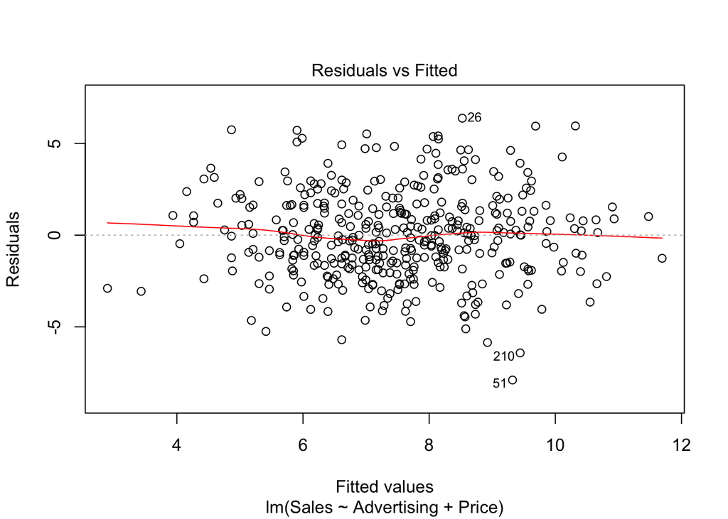

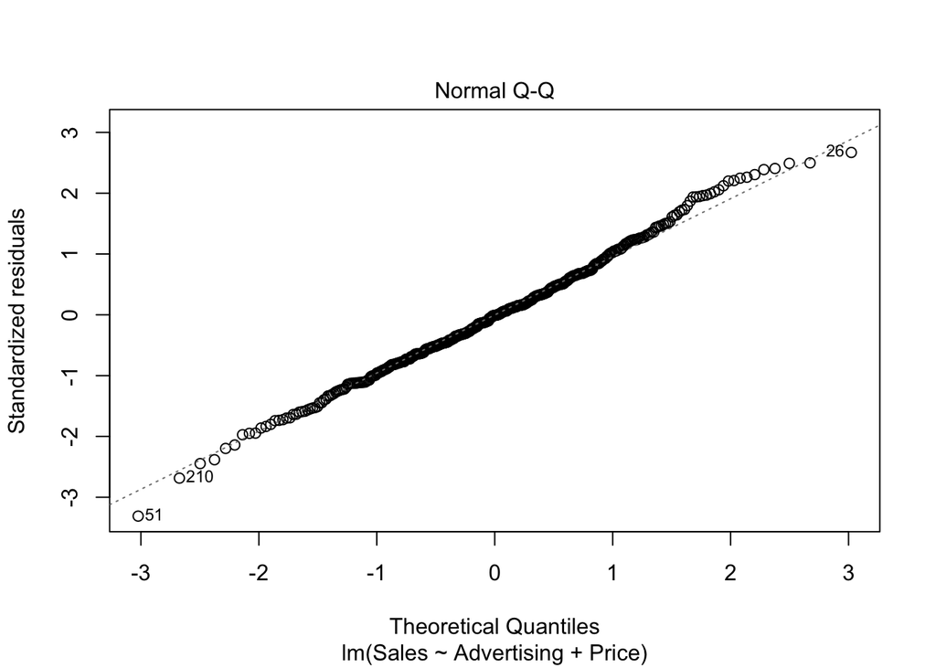

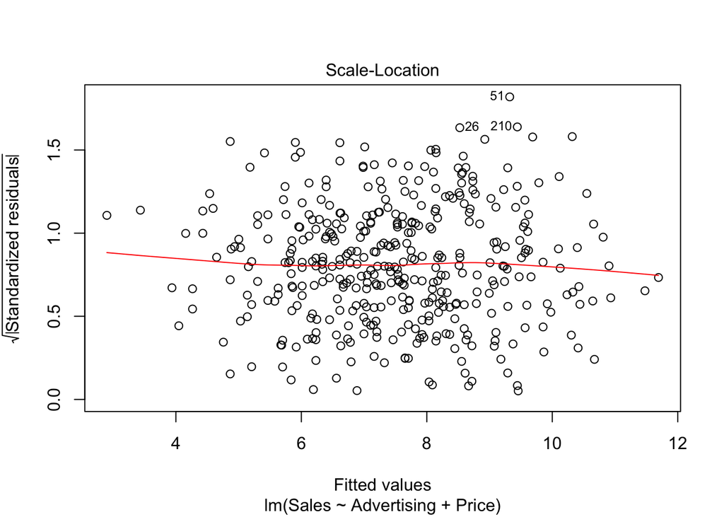

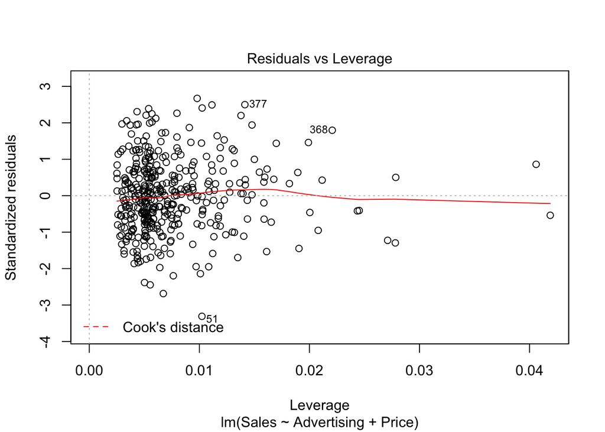

```r
plot(lm.fit)
```

**how Advertising and Price affect the Sales?**

**Intercept is most statistical significant as Pr(>|t|) is so small(2e-16) and t value is 21. It’s** *significant. Adverstisting has positive correlation with Sales, price is negative correlation with sales.Both are significant. The R square is 0.2819 which is not very high, which means the model has independent variables that are statistically significant but a low R-squared value.This combination indicates that the independent variables are correlated with the dependent variable, but they do not explain much of the variability in the dependent variable. The residual standard error is 2.399 which is quite low, that means it’s a good model. Price: suggests a relationship between price and sales given the low p-value of the F-statistic. The coefficient states a negative relationship between Price and Sales: as Price increases, Sales decreases.**

2. Fit a second model by adding Urban as an interactive variable with Advertising. Interpret the two new coefficients produced by adding this interaction to the Advertising variable that was already present from the first question, in a few statements.

## Answer:

```r
Carseats$Urban <- ifelse(Carseats$Urban=="Yes",1,0)

lm.fit2 <- lm(Sales ~ Advertising + Advertising:Urban + Price, data = Carseats)
summary(lm.fit2)
```

```
##
## Call:
## lm(formula = Sales ~ Advertising + Advertising:Urban + Price,
##     data = Carseats)
##
## Residuals:
##     Min      1Q  Median      3Q     Max
## -7.8701 -1.5629 -0.0274  1.5327  6.3786
##
## Coefficients:
##                    Estimate Std. Error t value Pr(>|t|)
## (Intercept)       12.992036   0.609830  21.304  < 2e-16 ***
## Advertising        0.127767   0.028036   4.557 6.91e-06 ***
## Price             -0.054520   0.005102 -10.685  < 2e-16 ***
## Advertising:Urban -0.006313   0.029004  -0.218    0.828
## ---
## Signif. codes:  0 '***' 0.001 '**' 0.01 '*' 0.05 '.' 0.1 ' ' 1
##
## Residual standard error: 2.402 on 396 degrees of freedom
## Multiple R-squared:  0.2819, Adjusted R-squared:  0.2765
## F-statistic: 51.83 on 3 and 396 DF,  p-value: < 2.2e-16
```

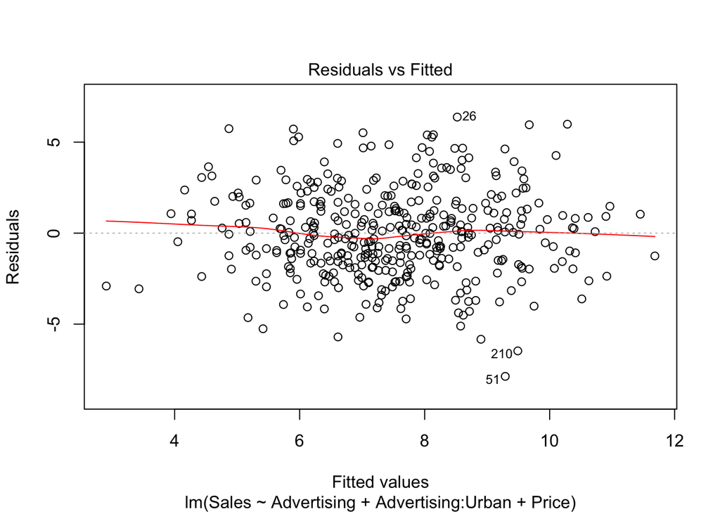

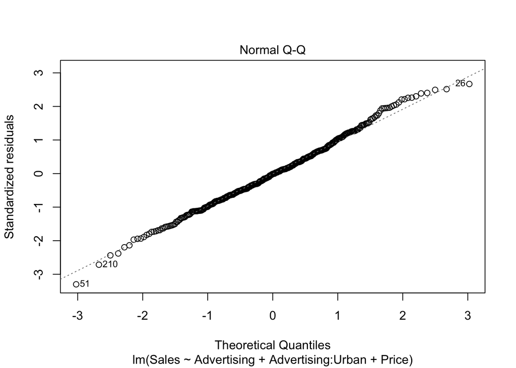

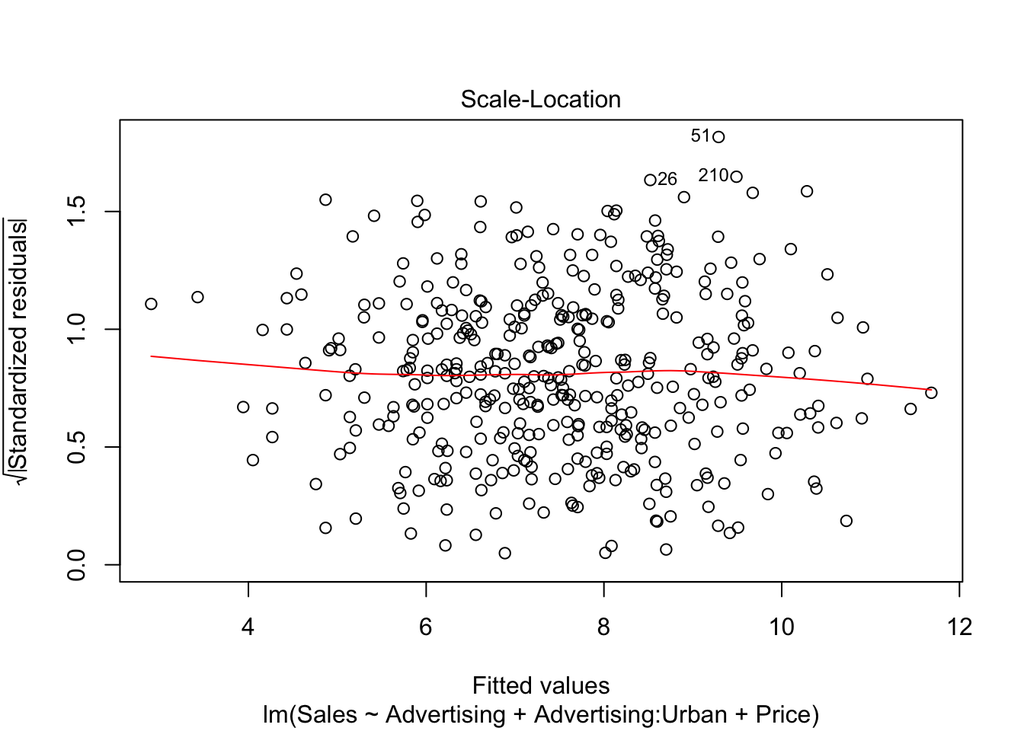

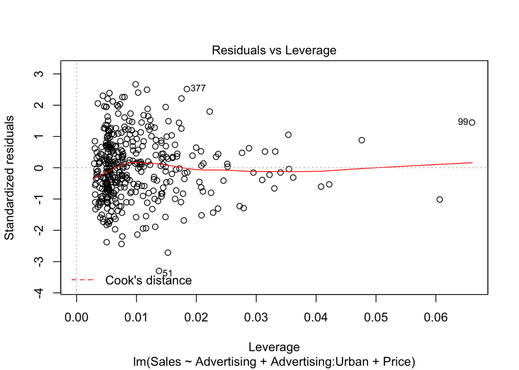

```r
plot(lm.fit2)
```

3. Which of these two models is preferable, and why?

**Choose the first model. Although the two models are quite similar as R sqaure are almost same. However the adjusted R square is bigger in the first model as it means it’s better to avoid overfitting. Also F statistics in the first model is larger thant the second model while p-value are almost the same, therefore, the overall fit of the first model is better than the second model.**

```r
simple_fit2 <- lm(Sales ~ Advertising + Advertising*Urban+Price, data = Carseats)
summary(simple_fit2)
```

```
##
## Call:
## lm(formula = Sales ~ Advertising + Advertising * Urban + Price,
##     data = Carseats)
##
## Residuals:
##     Min      1Q  Median      3Q     Max
## -7.8696 -1.5640 -0.0284  1.5323  6.3818
##
## Coefficients:
##                    Estimate Std. Error t value Pr(>|t|)
## (Intercept)       12.988703   0.666534  19.487  < 2e-16 ***
## Advertising        0.128015   0.034404   3.721 0.000227 ***
## Urban              0.004602   0.369040   0.012 0.990057
## Price             -0.054519   0.005110 -10.670  < 2e-16 ***
## Advertising:Urban -0.006666   0.040564  -0.164 0.869559
## ---
## Signif. codes:  0 '***' 0.001 '**' 0.01 '*' 0.05 '.' 0.1 ' ' 1
##
## Residual standard error: 2.405 on 395 degrees of freedom
## Multiple R-squared:  0.2819, Adjusted R-squared:  0.2747
## F-statistic: 38.77 on 4 and 395 DF,  p-value: < 2.2e-16
```

## Question 2:

You will need to load the core library for the course textbook and any other libraries you find suitable to answer the question:

```r
data("Weekly", package = "ISLR")
library("MASS")
library("class")
```

This question should be answered using the `Weekly` data set, which is part of the **ISLR** package. This data contains 1,089 weekly stock returns for 21 years, from the beginning of 1990 to the end of 2010.

1. Perform exploratory data analysis of the `Weekly` data (produce some numerical and graphical summaries). Discuss any patterns that emerge.

##answer:

```r
data("Weekly", package = "ISLR")
head(Weekly)
```

```
##   Year   Lag1   Lag2   Lag3   Lag4   Lag5    Volume  Today Direction
## 1 1990  0.816  1.572 -3.936 -0.229 -3.484 0.1549760 -0.270      Down
## 2 1990 -0.270  0.816  1.572 -3.936 -0.229 0.1485740 -2.576      Down
## 3 1990 -2.576 -0.270  0.816  1.572 -3.936 0.1598375  3.514        Up
## 4 1990  3.514 -2.576 -0.270  0.816  1.572 0.1616300  0.712        Up
## 5 1990  0.712  3.514 -2.576 -0.270  0.816 0.1537280  1.178        Up
## 6 1990  1.178  0.712  3.514 -2.576 -0.270 0.1544440 -1.372      Down
```

```r
Weekly$Direction <- ifelse(Weekly$Direction== "Up",1,0)
summary(Weekly)
```

```
##       Year           Lag1               Lag2               Lag3
##  Min.   :1990   Min.   :-18.1950   Min.   :-18.1950   Min.   :-18.1950
##  1st Qu.:1995   1st Qu.: -1.1540   1st Qu.: -1.1540   1st Qu.: -1.1580
##  Median :2000   Median :  0.2410   Median :  0.2410   Median :  0.2410
##  Mean   :2000   Mean   :  0.1506   Mean   :  0.1511   Mean   :  0.1472
##  3rd Qu.:2005   3rd Qu.:  1.4050   3rd Qu.:  1.4090   3rd Qu.:  1.4090
##  Max.   :2010   Max.   : 12.0260   Max.   : 12.0260   Max.   : 12.0260
##       Lag4               Lag5              Volume
##  Min.   :-18.1950   Min.   :-18.1950   Min.   :0.08747
##  1st Qu.: -1.1580   1st Qu.: -1.1660   1st Qu.:0.33202
##  Median :  0.2380   Median :  0.2340   Median :1.00268
##  Mean   :  0.1458   Mean   :  0.1399   Mean   :1.57462
##  3rd Qu.:  1.4090   3rd Qu.:  1.4050   3rd Qu.:2.05373
##  Max.   : 12.0260   Max.   : 12.0260   Max.   :9.32821
##      Today            Direction
##  Min.   :-18.1950   Min.   :0.0000
##  1st Qu.: -1.1540   1st Qu.:0.0000
##  Median :  0.2410   Median :1.0000
##  Mean   :  0.1499   Mean   :0.5556
##  3rd Qu.:  1.4050   3rd Qu.:1.0000
##  Max.   : 12.0260   Max.   :1.0000
```

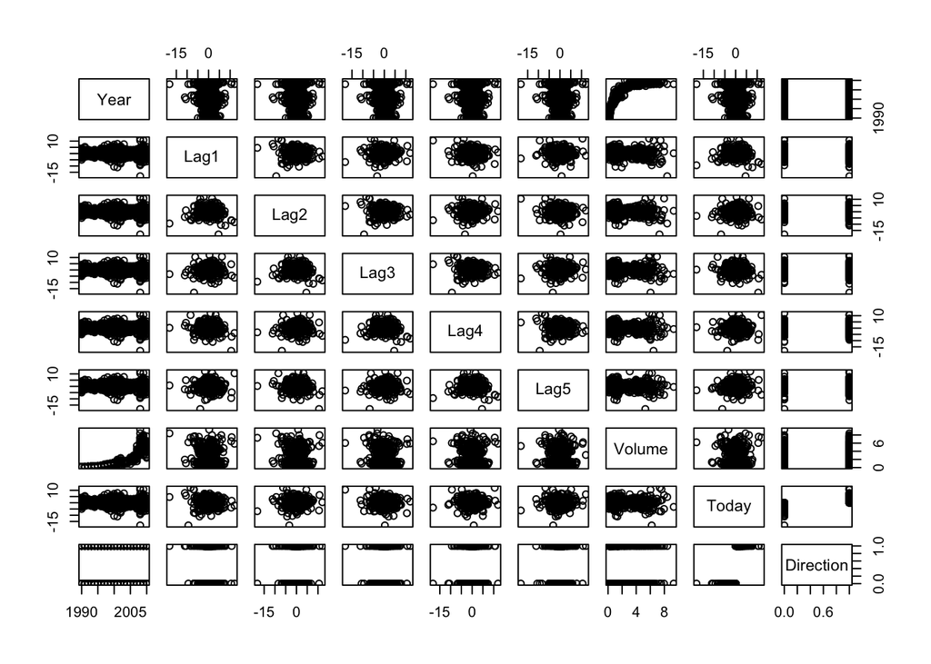

```r
pairs(Weekly)
```

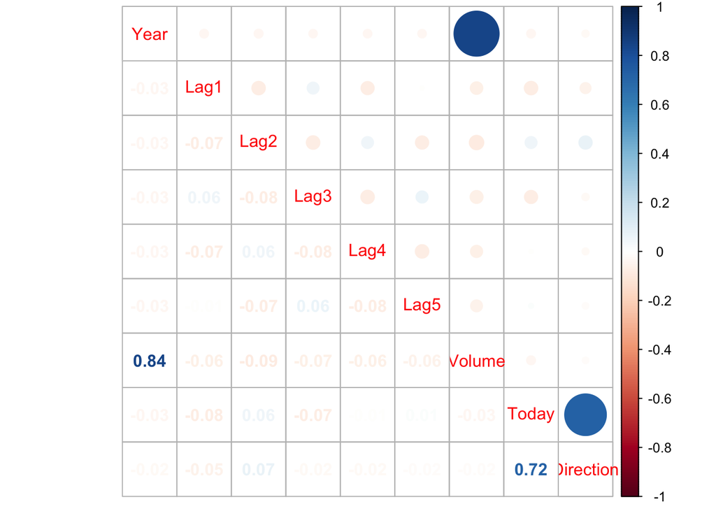

```r
corrplot::corrplot.mixed(cor(Weekly),upper="circle")
```

**Volume and Year are related.** **Year and volumn has 0.84 relation, Today and direction has 0.72 corrolation**

2. Fit a logistic regression with `Direction` as the response and different combinations of lag variables plus `Volume` as predictors. Use the period from 1990 to 2008 as your training set and 2009-2010 as your test set. Produce a summary of results.

```r
train <- subset(Weekly,Year= 1990 & Year <= 2008)
test <- subset(Weekly,Year==2009 | Year==2010)
lag1_volume_fit <- glm(Direction~Lag1+Volume, data=train, family="binomial")
probs <- predict(lag1_volume_fit, test, type="response")
pred.glm <- rep(0, length(probs))
pred.glm[probs > 0.5] <- 1
mean(pred.glm != test$Direction)
```

```
## [1] 0.4423077
```

```r
lag2_volume_fit <- glm(Direction~Lag2+Volume, data=train, family="binomial")
probs <- predict(lag2_volume_fit, test, type="response")
pred.glm <- rep(0, length(probs))

pred.glm[probs > 0.5] <- 1
table(pred.glm,test$Direction)
```

```
##
## pred.glm  0  1
##        0  9  6
##        1 34 55
```

```r
mean(pred.glm != test$Direction)
```

```
## [1] 0.3846154
```

```r
lag3_volume_fit <- glm(Direction~Lag3+Volume, data=train, family="binomial")
probs <- predict(lag3_volume_fit, test, type="response")
pred.glm <- rep(0, length(probs))

pred.glm[probs > 0.5] <- 1
mean(pred.glm != test$Direction)
```

```
## [1] 0.4423077
```

```r
lag4_volume_fit <- glm(Direction~Lag4+Volume, data=train, family="binomial")
probs <- predict(lag4_volume_fit, test, type="response")
pred.glm <- rep(0, length(probs))

pred.glm[probs > 0.5] <- 1
mean(pred.glm != test$Direction)
```

```
## [1] 0.3846154
```

```r
lag5_volume_fit <- glm(Direction~Lag5+Volume, data=train, family="binomial")
probs <- predict(lag5_volume_fit, test, type="response")
pred.glm <- rep(0, length(probs))
pred.glm[probs > 0.5] <- 1
mean(pred.glm != test$Direction)
```

```
## [1] 0.4326923
```

```r
lag1_lag2_volume_fit <- glm(Direction~Lag1+Lag2+Volume, data=train, family="binomial")
probs <- predict(lag1_lag2_volume_fit, test, type="response")
pred.glm <- rep(0, length(probs))
pred.glm[probs > 0.5] <- 1
mean(pred.glm != test$Direction)
```

```
## [1] 0.3942308
```

```r
lag1_lag2_lag3_volume_fit <- glm(Direction~Lag1+Lag2+Lag3+Volume, data=train, family="binomial")
probs <- predict(lag1_lag2_lag3_volume_fit, test, type="response")
pred.glm <- rep(0, length(probs))
pred.glm[probs > 0.5] <- 1
mean(pred.glm != test$Direction)
```

```
## [1] 0.3846154
```

```r
lag2_lag3_volume_fit <- glm(Direction~Lag2+Lag3+Volume, data=train, family="binomial")
probs <- predict(lag2_lag3_volume_fit, test, type="response")
pred.glm <- rep(0, length(probs))
pred.glm[probs > 0.5] <- 1
mean(pred.glm != test$Direction)
```

```
## [1] 0.375
```

```r
##best mean

lag3_lag4_volume_fit <- glm(Direction~Lag3+Lag4+Volume, data=train, family="binomial")
probs <- predict(lag3_lag4_volume_fit, test, type="response")
pred.glm <- rep(0, length(probs))
pred.glm[probs > 0.5] <- 1
mean(pred.glm != test$Direction)
```

```
## [1] 0.4519231
```

```r
lag4_lag5_volume_fit <- glm(Direction~Lag4+Lag5+Volume, data=train, family="binomial")
probs <- predict(lag4_lag5_volume_fit, test, type="response")
pred.glm <- rep(0, length(probs))
pred.glm[probs > 0.5] <- 1
mean(pred.glm != test$Direction)
```

```
## [1] 0.4326923
```

```r
lag2_lag4_volume_fit <- glm(Direction~Lag2+Lag4+Volume, data=train, family="binomial")
probs <- predict(lag2_lag4_volume_fit, test, type="response")
pred.glm <- rep(0, length(probs))
pred.glm[probs > 0.5] <- 1
mean(pred.glm != test$Direction)
```

```
## [1] 0.3942308
```

```r
lag2_lag5_volume_fit <- glm(Direction~Lag2+Lag5+Volume, data=train, family="binomial")
probs <- predict(lag2_lag5_volume_fit, test, type="response")
pred.glm <- rep(0, length(probs))
pred.glm[probs > 0.5] <- 1
mean(pred.glm != test$Direction)
```

```
## [1] 0.3942308
```

[output not shown]

3. From your test set, compute the confusion matrix, and calculate accuracy, precision, recall and F1.

**confution matrix**

```r
confusion_matrix <- table(pred.glm,test$Direction)

confusion_matrix[1,1]
```

```
## [1] 10
```

```r
confusion_matrix[1,2]
```

```
## [1] 8
```

```r
confusion_matrix[2,2]
```

```
## [1] 53
```

```r
confusion_matrix[2,1]
```

```
## [1] 33
```

**precision**

```r
precision <- confusion_matrix[2,2]/(confusion_matrix[2,2]+confusion_matrix[1,2])
precision
```

```
## [1] 0.8688525
```

**recall**

```r
recall <-confusion_matrix[2,2]/(confusion_matrix[2,2]+confusion_matrix[2,1])
recall
```

```
## [1] 0.6162791
```

**F1**

```r
F1 <- 2*precision*recall/(precision+recall)
F1
```

```
## [1] 0.7210884
```

**accuracy**

```r
accuracy <- (confusion_matrix[1,1])+confusion_matrix[2,2]/(sum(confusion_matrix))
accuracy
```

```
## [1] 10.50962
```

```r
lag2_lag3_volume_fit <- glm(Direction~Lag2+Lag3+Volume, data=train, family="binomial")
probs <- predict(lag2_lag3_volume_fit, test, type="response")
pred.glm <- rep(0, length(probs))
pred.glm[probs > 0.5] <- 1
 table(pred.glm,test$Direction)
```

```
##
## pred.glm  0  1
##        0 11  7
##        1 32 54
```

```r
mean(pred.glm != test$Direction)
```

```
## [1] 0.375
```

4. (Extra credit) Experiment with alternative classification methods.

   Present the results of your experiments reporting method, associated confusion matrix, and measures of fit on the test set like accuracy, precision, recall, and F1.

**lda model**

```r
lda_model <- lda(Direction~Lag2+Lag3+Volume, data=train)
lda_pred = predict(lda_model, test)
table(lda_pred$class,test$Direction)
```

```
##
##      0  1
##   0 11  7
##   1 32 54
```

```r
mean(lda_pred$class!=test$Direction)
```

```
## [1] 0.375
```

**qda model**

```r
qda_model <- qda(Direction~Lag2+Lag3+Volume, data=train)
qda_pred = predict(qda_model, test)
table(qda_pred$class,test$Direction)
```

```
##
##      0  1
##   0 16 18
##   1 27 43
```

```r
mean(qda_pred$class!=test$Direction)
```

```
## [1] 0.4326923
```

**knn**

```r
train$Today <- NULL
test$Today <- NULL
knn_pred_y <- knn(train,test,train$Direction,k=1)
table(knn_pred_y, test$Direction)
```

```
##
## knn_pred_y  0  1
##          0 43  0
##          1  0 61
```

```r
mean(knn_pred_y!=test$Direction)
```

```
## [1] 0
```

**best solution**

**find optimum k**

```r
knn_pred_y = NULL
error_rate = NULL
for(i in 1:dim(test)[1]){
set.seed(1234)
knn_pred_y = knn(train,test,train$Direction,k=i)
error_rate[i] = mean(test$Direction != knn_pred_y)
}
```

**find the minimum error rate**

```r
min_error_rate = min(error_rate)
print(min_error_rate)
```

```
## [1] 0
```

```r
knn_pred_y <- knn(train,test,train$Direction,k=42)
table(knn_pred_y, test$Direction)
```

```
##
## knn_pred_y  0  1
##          0 13  8
##          1 30 53
```

```r
mean(knn_pred_y!=test$Direction)
```

```
## [1] 0.3653846
```